# Data603Project

Ikeora Ekene, Virani Adam, Obi Anthony, Hawkson Chris, Aidoo, Maria

2024-11-21

# Setup

Loading Libraries

Importing the Data

```r
LifeExpectancy=read.csv("Life-Expectancy-Data.csv")
LifeExpectancy
```

| Country | Region | Year | Infant_deaths | Under_five_deaths | Adult_mortality | Alcohol_consumption | Hepatitis_B | Measles | BMI | Polio | Diphtheria | Incidents_HIV | GDP_per_capita | Population_mln | Thinness_ten_nineteen_years | Thinness_five_nine_years | Schooling | Economy_status_Developed | Economy_status_Developing | Life_expectancy |
| --- | --- | --- | --- | --- | --- | --- | --- | --- | --- | --- | --- | --- | --- | --- | --- | --- | --- | --- | --- | --- |
| Turkiye | Middle East | 2015 | 11.1 | 13.0 | 105.8240 | 1.3200 | 97 | 65 | 27.8 | 97 | 97 | 0.08 | 11006 | 78.53 | 4.9 | 4.8 | 7.8 | 0 | 1 | 76.5 |
| Spain | European Union | 2015 | 2.7 | 3.3 | 57.9025 | 10.3500 | 97 | 94 | 26.0 | 97 | 97 | 0.09 | 25742 | 46.44 | 0.6 | 0.5 | 9.7 | 1 | 0 | 82.8 |
| India | Asia | 2007 | 51.5 | 67.9 | 201.0765 | 1.5700 | 60 | 35 | 21.2 | 67 | 64 | 0.13 | 1076 | 1183.21 | 27.1 | 28.0 | 5.0 | 0 | 1 | 65.4 |
| Guyana | South America | 2006 | 32.8 | 40.5 | 222.1965 | 5.6800 | 93 | 74 | 25.3 | 92 | 93 | 0.79 | 4146 | 0.75 | 5.7 | 5.5 | 7.9 | 0 | 1 | 67.0 |
| Israel | Middle East | 2012 | 3.4 | 4.3 | 57.9510 | 2.8900 | 97 | 89 | 27.0 | 94 | 94 | 0.08 | 33995 | 7.91 | 1.2 | 1.1 | 12.8 | 1 | 0 | 81.7 |
| Costa Rica | Central America and Caribbean | 2006 | 9.8 | 11.2 | 95.2200 | 4.1900 | 88 | 86 | 26.4 | 89 | 89 | 0.16 | 9110 | 4.35 | 2.0 | 1.9 | 7.9 | 0 | 1 | 78.2 |
| Russian Federation | Rest of Europe | 2015 | 6.6 | 8.2 | 223.0000 | 8.0600 | 97 | 97 | 26.2 | 97 | 97 | 0.08 | 9313 | 144.10 | 2.3 | 2.3 | 12.0 | 0 | 1 | 71.2 |
| Hungary | European Union | 2000 | 8.7 | 10.1 | 192.9690 | 12.2300 | 88 | 99 | 25.9 | 99 | 99 | 0.08 | 8971 | 10.21 | 2.3 | 2.3 | 10.2 | 1 | 0 | 71.2 |
| Jordan | Middle East | 2001 | 22.0 | 26.1 | 129.7640 | 0.5200 | 97 | 87 | 27.9 | 97 | 99 | 0.13 | 3708 | 5.22 | 4.0 | 3.9 | 9.6 | 0 | 1 | 71.9 |
| Moldova | Rest of Europe | 2008 | 15.3 | 17.8 | 217.8570 | 7.7200 | 97 | 92 | 26.5 | 96 | 90 | 0.43 | 2235 | 2.87 | 2.9 | 3.1 | 10.9 | 0 | 1 | 68.7 |

[output cut: 990 more lines]

Data Cleaning and Checking

```r
## checks for missing values in each column
sapply(LifeExpectancy, function (x) sum(is.na(x)))
```

```
                    Country                      Region                        Year
                          0                           0                           0
              Infant_deaths           Under_five_deaths             Adult_mortality
                          0                           0                           0
        Alcohol_consumption                 Hepatitis_B                     Measles
                          0                           0                           0
                        BMI                       Polio                  Diphtheria
                          0                           0                           0
              Incidents_HIV              GDP_per_capita              Population_mln
                          0                           0                           0
Thinness_ten_nineteen_years    Thinness_five_nine_years                   Schooling
                          0                           0                           0
   Economy_status_Developed   Economy_status_Developing             Life_expectancy
                          0                           0                           0
```

No null values found

```r
size=dim(LifeExpectancy)
cat("The dataset has a total of", size[1],"rows and",size[2],"columns")
```

```
The dataset has a total of 2864 rows and 21 columns
```

```r
# glimpse of the data
str(LifeExpectancy)
```

```
'data.frame':   2864 obs. of  21 variables:
 $ Country                    : chr  "Turkiye" "Spain" "India" "Guyana" ...
 $ Region                     : chr  "Middle East" "European Union" "Asia" "South America" ...
 $ Year                       : int  2015 2015 2007 2006 2012 2006 2015 2000 2001 2008 ...
 $ Infant_deaths              : num  11.1 2.7 51.5 32.8 3.4 9.8 6.6 8.7 22 15.3 ...
 $ Under_five_deaths          : num  13 3.3 67.9 40.5 4.3 11.2 8.2 10.1 26.1 17.8 ...
 $ Adult_mortality            : num  105.8 57.9 201.1 222.2 58 ...
 $ Alcohol_consumption        : num  1.32 10.35 1.57 5.68 2.89 ...
 $ Hepatitis_B                : int  97 97 60 93 97 88 97 88 97 97 ...
 $ Measles                    : int  65 94 35 74 89 86 97 99 87 92 ...
 $ BMI                        : num  27.8 26 21.2 25.3 27 26.4 26.2 25.9 27.9 26.5 ...
 $ Polio                      : int  97 97 67 92 94 89 97 99 97 96 ...
 $ Diphtheria                 : int  97 97 64 93 94 89 97 99 99 90 ...
 $ Incidents_HIV              : num  0.08 0.09 0.13 0.79 0.08 0.16 0.08 0.08 0.13 0.43 ...
 $ GDP_per_capita             : int  11006 25742 1076 4146 33995 9110 9313 8971 3708 2235 ...
 $ Population_mln             : num  78.53 46.44 1183.21 0.75 7.91 ...
 $ Thinness_ten_nineteen_years: num  4.9 0.6 27.1 5.7 1.2 2 2.3 2.3 4 2.9 ...
 $ Thinness_five_nine_years   : num  4.8 0.5 28 5.5 1.1 1.9 2.3 2.3 3.9 3.1 ...
 $ Schooling                  : num  7.8 9.7 5 7.9 12.8 7.9 12 10.2 9.6 10.9 ...
 $ Economy_status_Developed   : int  0 1 0 0 1 0 0 1 0 0 ...
 $ Economy_status_Developing  : int  1 0 1 1 0 1 1 0 1 1 ...
 $ Life_expectancy            : num  76.5 82.8 65.4 67 81.7 78.2 71.2 71.2 71.9 68.7 ...
```

Distribution of Life Expectancy

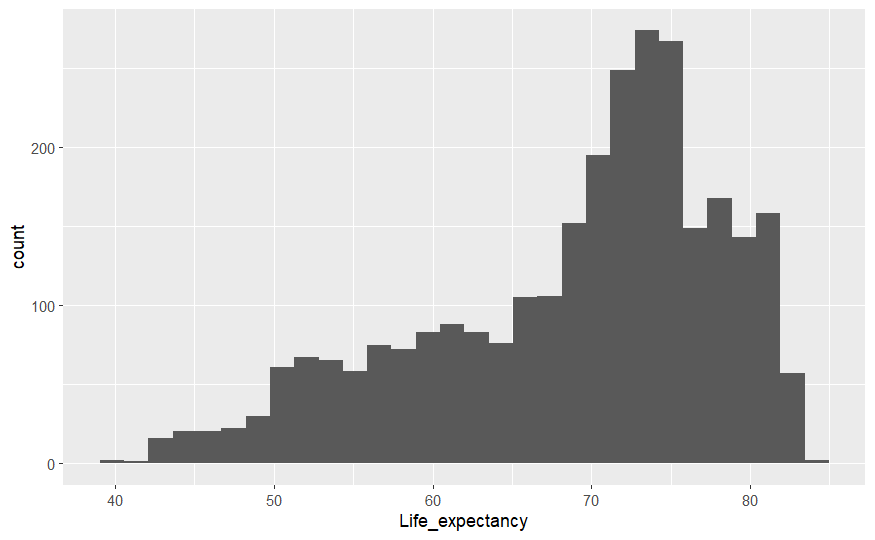

```r
ggplot(data=LifeExpectancy,aes(Life_expectancy))+
geom_histogram()
```

Left skewed distribution

# Initial Model

Full Regression model

```r
LifeExpectancyModel=lm(Life_expectancy~Infant_deaths+Under_five_deaths+Adult_mortality+Alcohol_consumption+Hepatitis_B+Measles+BMI+Polio+Diphtheria+Incidents_HIV+GDP_per_capita+Population_mln+Thinness_ten_nineteen_years+Thinness_five_nine_years+Schooling+Economy_status_Developed,data=LifeExpectancy)

summary(LifeExpectancyModel)
```

```
Call:
lm(formula = Life_expectancy ~ Infant_deaths + Under_five_deaths +
    Adult_mortality + Alcohol_consumption + Hepatitis_B + Measles +
    BMI + Polio + Diphtheria + Incidents_HIV + GDP_per_capita +
    Population_mln + Thinness_ten_nineteen_years + Thinness_five_nine_years +
    Schooling + Economy_status_Developed, data = LifeExpectancy)

Residuals:
    Min      1Q  Median      3Q     Max
-4.7613 -0.8923 -0.0699  0.8606  8.0965

Coefficients:
                              Estimate Std. Error t value Pr(>|t|)
(Intercept)                  8.452e+01  6.148e-01 137.481  < 2e-16 ***
Infant_deaths               -4.791e-02  6.180e-03  -7.752 1.25e-14 ***
Under_five_deaths           -5.603e-02  3.841e-03 -14.588  < 2e-16 ***
Adult_mortality             -4.829e-02  6.204e-04 -77.831  < 2e-16 ***
Alcohol_consumption          6.417e-02  9.914e-03   6.473 1.13e-10 ***
Hepatitis_B                 -7.691e-03  2.558e-03  -3.006  0.00267 **
Measles                      1.390e-03  1.718e-03   0.809  0.41835
BMI                         -1.455e-01  1.915e-02  -7.600 3.99e-14 ***
Polio                        2.300e-03  5.845e-03   0.393  0.69404
Diphtheria                   8.558e-04  5.904e-03   0.145  0.88476
Incidents_HIV                9.465e-02  1.819e-02   5.205 2.08e-07 ***
GDP_per_capita               2.548e-05  2.289e-06  11.130  < 2e-16 ***
Population_mln              -1.342e-04  2.000e-04  -0.671  0.50229
Thinness_ten_nineteen_years -3.368e-02  1.715e-02  -1.964  0.04962 *
Thinness_five_nine_years     2.573e-03  1.682e-02   0.153  0.87845
Schooling                    9.531e-02  1.681e-02   5.669 1.58e-08 ***
Economy_status_Developed     6.442e-01  1.082e-01   5.954 2.93e-09 ***
---
Signif. codes:  0 ‘***’ 0.001 ‘**’ 0.01 ‘*’ 0.05 ‘.’ 0.1 ‘ ’ 1

Residual standard error: 1.361 on 2847 degrees of freedom
Multiple R-squared:  0.9792,    Adjusted R-squared:  0.9791
F-statistic:  8368 on 16 and 2847 DF,  p-value: < 2.2e-16
```

Multicolinerity Check

```r
imcdiag(LifeExpectancyModel,method='VIF')
```

```
Call:
imcdiag(mod = LifeExpectancyModel, method = "VIF")


 VIF Multicollinearity Diagnostics

                                VIF detection
Infant_deaths               44.7615         1
Under_five_deaths           45.2903         1
Adult_mortality              7.8560         0
Alcohol_consumption          2.4089         0
Hepatitis_B                  2.5885         0
Measles                      1.5878         0
BMI                          2.7274         0
Polio                       12.0104         1
Diphtheria                  13.0010         1
Incidents_HIV                2.8988         0
GDP_per_capita               2.3232         0
Population_mln               1.1519         0
Thinness_ten_nineteen_years  8.9502         0
Thinness_five_nine_years     8.9586         0
Schooling                    4.3943         0
Economy_status_Developed     2.9678         0

Multicollinearity may be due to Infant_deaths Under_five_deaths Polio Diphtheria regressors

1 --> COLLINEARITY is detected by the test
0 --> COLLINEARITY is not detected by the test

===================================
```

Removing Infant Deaths and Diphtheria

```r
LifeExpectancyModel=lm(Life_expectancy~Under_five_deaths+Adult_mortality+Alcohol_consumption+Hepatitis_B+Measles+BMI+Polio+Incidents_HIV+GDP_per_capita+Population_mln+Thinness_ten_nineteen_years+Thinness_five_nine_years+Schooling+Economy_status_Developed,data=LifeExpectancy)

summary(LifeExpectancyModel)
```

```
Call:
lm(formula = Life_expectancy ~ Under_five_deaths + Adult_mortality +
    Alcohol_consumption + Hepatitis_B + Measles + BMI + Polio +
    Incidents_HIV + GDP_per_capita + Population_mln + Thinness_ten_nineteen_years +
    Thinness_five_nine_years + Schooling + Economy_status_Developed,
    data = LifeExpectancy)

Residuals:
    Min      1Q  Median      3Q     Max
-5.0564 -0.8965 -0.0640  0.8776  9.0904

Coefficients:
                              Estimate Std. Error t value Pr(>|t|)
(Intercept)                  8.408e+01  6.142e-01 136.893  < 2e-16 ***
Under_five_deaths           -8.293e-02  1.633e-03 -50.772  < 2e-16 ***
Adult_mortality             -4.869e-02  6.245e-04 -77.959  < 2e-16 ***
Alcohol_consumption          7.482e-02  9.918e-03   7.543 6.13e-14 ***
Hepatitis_B                 -5.867e-03  2.387e-03  -2.458   0.0140 *
Measles                      1.899e-03  1.733e-03   1.096   0.2731
BMI                         -1.483e-01  1.923e-02  -7.713 1.69e-14 ***
Polio                        3.333e-03  3.286e-03   1.014   0.3105
Incidents_HIV                1.096e-01  1.826e-02   5.999 2.23e-09 ***
GDP_per_capita               2.782e-05  2.292e-06  12.138  < 2e-16 ***
Population_mln              -1.593e-04  2.020e-04  -0.789   0.4302
Thinness_ten_nineteen_years -3.320e-02  1.730e-02  -1.919   0.0551 .
Thinness_five_nine_years    -3.411e-03  1.697e-02  -0.201   0.8407
Schooling                    9.497e-02  1.698e-02   5.593 2.44e-08 ***
Economy_status_Developed     7.239e-01  1.086e-01   6.669 3.09e-11 ***
---
Signif. codes:  0 ‘***’ 0.001 ‘**’ 0.01 ‘*’ 0.05 ‘.’ 0.1 ‘ ’ 1

Residual standard error: 1.375 on 2849 degrees of freedom
Multiple R-squared:  0.9787,    Adjusted R-squared:  0.9786
F-statistic:  9368 on 14 and 2849 DF,  p-value: < 2.2e-16
```

```r
imcdiag(LifeExpectancyModel,method='VIF')
```

```
Call:
imcdiag(mod = LifeExpectancyModel, method = "VIF")


 VIF Multicollinearity Diagnostics

                               VIF detection
Under_five_deaths           8.0270         0
Adult_mortality             7.8012         0
Alcohol_consumption         2.3626         0
Hepatitis_B                 2.2072         0
Measles                     1.5837         0
BMI                         2.6953         0
Polio                       3.7190         0
Incidents_HIV               2.8655         0
GDP_per_capita              2.2816         0
Population_mln              1.1508         0
Thinness_ten_nineteen_years 8.9330         0
Thinness_five_nine_years    8.9340         0
Schooling                   4.3926         0
Economy_status_Developed    2.9279         0

NOTE:  VIF Method Failed to detect multicollinearity


0 --> COLLINEARITY is not detected by the test

===================================
```

Finding the best additive model using stepwise both

```r
ModelStepwise=ols_step_both_p(LifeExpectancyModel,p_remove=0.1,p_enter = 0.05)
summary(ModelStepwise$model)
```

```
Call:
lm(formula = paste(response, "~", paste(preds, collapse = " + ")),
    data = l)

Residuals:
    Min      1Q  Median      3Q     Max
-5.0447 -0.8953 -0.0721  0.8814  9.1654

Coefficients:
                              Estimate Std. Error t value Pr(>|t|)
(Intercept)                  8.394e+01  5.173e-01 162.263  < 2e-16 ***
Adult_mortality             -4.865e-02  6.193e-04 -78.555  < 2e-16 ***
Under_five_deaths           -8.277e-02  1.404e-03 -58.936  < 2e-16 ***
Economy_status_Developed     7.465e-01  1.080e-01   6.910 5.97e-12 ***
GDP_per_capita               2.808e-05  2.286e-06  12.283  < 2e-16 ***
Alcohol_consumption          7.456e-02  9.892e-03   7.537 6.40e-14 ***
Schooling                    9.724e-02  1.677e-02   5.798 7.43e-09 ***
BMI                         -1.465e-01  1.872e-02  -7.828 6.92e-15 ***
Incidents_HIV                1.076e-01  1.806e-02   5.956 2.90e-09 ***
Thinness_ten_nineteen_years -3.790e-02  7.984e-03  -4.747 2.17e-06 ***
---
Signif. codes:  0 ‘***’ 0.001 ‘**’ 0.01 ‘*’ 0.05 ‘.’ 0.1 ‘ ’ 1

Residual standard error: 1.375 on 2854 degrees of freedom
Multiple R-squared:  0.9787,    Adjusted R-squared:  0.9786
F-statistic: 1.456e+04 on 9 and 2854 DF,  p-value: < 2.2e-16
```

Forward StepWise Model

```r
ForwardModelStepwise=ols_step_forward_p(LifeExpectancyModel,p_val=0.05)
summary(ForwardModelStepwise$model)
```

```
Call:
lm(formula = paste(response, "~", paste(preds, collapse = " + ")),
    data = l)

Residuals:
    Min      1Q  Median      3Q     Max
-5.0447 -0.8953 -0.0721  0.8814  9.1654

Coefficients:
                              Estimate Std. Error t value Pr(>|t|)
(Intercept)                  8.394e+01  5.173e-01 162.263  < 2e-16 ***
Adult_mortality             -4.865e-02  6.193e-04 -78.555  < 2e-16 ***
Under_five_deaths           -8.277e-02  1.404e-03 -58.936  < 2e-16 ***
Economy_status_Developed     7.465e-01  1.080e-01   6.910 5.97e-12 ***
GDP_per_capita               2.808e-05  2.286e-06  12.283  < 2e-16 ***
Alcohol_consumption          7.456e-02  9.892e-03   7.537 6.40e-14 ***
Schooling                    9.724e-02  1.677e-02   5.798 7.43e-09 ***
BMI                         -1.465e-01  1.872e-02  -7.828 6.92e-15 ***
Incidents_HIV                1.076e-01  1.806e-02   5.956 2.90e-09 ***
Thinness_ten_nineteen_years -3.790e-02  7.984e-03  -4.747 2.17e-06 ***
---
Signif. codes:  0 ‘***’ 0.001 ‘**’ 0.01 ‘*’ 0.05 ‘.’ 0.1 ‘ ’ 1

Residual standard error: 1.375 on 2854 degrees of freedom
Multiple R-squared:  0.9787,    Adjusted R-squared:  0.9786
F-statistic: 1.456e+04 on 9 and 2854 DF,  p-value: < 2.2e-16
```

BackWards StepWise Model

```r
BackwardModelStepwise=ols_step_backward_p(LifeExpectancyModel,p_val=0.05)
summary(BackwardModelStepwise$model)
```

```
Call:
lm(formula = paste(response, "~", paste(c(include, cterms), collapse = " + ")),
    data = l)

Residuals:
    Min      1Q  Median      3Q     Max
-5.0447 -0.8953 -0.0721  0.8814  9.1654

Coefficients:
                              Estimate Std. Error t value Pr(>|t|)
(Intercept)                  8.394e+01  5.173e-01 162.263  < 2e-16 ***
Under_five_deaths           -8.277e-02  1.404e-03 -58.936  < 2e-16 ***
Adult_mortality             -4.865e-02  6.193e-04 -78.555  < 2e-16 ***
Alcohol_consumption          7.456e-02  9.892e-03   7.537 6.40e-14 ***
BMI                         -1.465e-01  1.872e-02  -7.828 6.92e-15 ***
Incidents_HIV                1.076e-01  1.806e-02   5.956 2.90e-09 ***
GDP_per_capita               2.808e-05  2.286e-06  12.283  < 2e-16 ***
Thinness_ten_nineteen_years -3.790e-02  7.984e-03  -4.747 2.17e-06 ***
Schooling                    9.724e-02  1.677e-02   5.798 7.43e-09 ***
Economy_status_Developed     7.465e-01  1.080e-01   6.910 5.97e-12 ***
---
Signif. codes:  0 ‘***’ 0.001 ‘**’ 0.01 ‘*’ 0.05 ‘.’ 0.1 ‘ ’ 1

Residual standard error: 1.375 on 2854 degrees of freedom
Multiple R-squared:  0.9787,    Adjusted R-squared:  0.9786
F-statistic: 1.456e+04 on 9 and 2854 DF,  p-value: < 2.2e-16
```

All 3 stepwise methods resulted in the same model

# Final Additive Model

```r
Best_Additive_Model=lm(Life_expectancy~
    Under_five_deaths +
    Adult_mortality +
    Alcohol_consumption +
    BMI +
     Incidents_HIV +
     GDP_per_capita +
     Thinness_ten_nineteen_years+
     Schooling +
    Economy_status_Developed ,
    data=LifeExpectancy)
summary(Best_Additive_Model)
```

```
Call:
lm(formula = Life_expectancy ~ Under_five_deaths + Adult_mortality +
    Alcohol_consumption + BMI + Incidents_HIV + GDP_per_capita +
    Thinness_ten_nineteen_years + Schooling + Economy_status_Developed,
    data = LifeExpectancy)

Residuals:
    Min      1Q  Median      3Q     Max
-5.0447 -0.8953 -0.0721  0.8814  9.1654

Coefficients:
                              Estimate Std. Error t value Pr(>|t|)
(Intercept)                  8.394e+01  5.173e-01 162.263  < 2e-16 ***
Under_five_deaths           -8.277e-02  1.404e-03 -58.936  < 2e-16 ***
Adult_mortality             -4.865e-02  6.193e-04 -78.555  < 2e-16 ***
Alcohol_consumption          7.456e-02  9.892e-03   7.537 6.40e-14 ***
BMI                         -1.465e-01  1.872e-02  -7.828 6.92e-15 ***
Incidents_HIV                1.076e-01  1.806e-02   5.956 2.90e-09 ***
GDP_per_capita               2.808e-05  2.286e-06  12.283  < 2e-16 ***
Thinness_ten_nineteen_years -3.790e-02  7.984e-03  -4.747 2.17e-06 ***
Schooling                    9.724e-02  1.677e-02   5.798 7.43e-09 ***
Economy_status_Developed     7.465e-01  1.080e-01   6.910 5.97e-12 ***
---
Signif. codes:  0 ‘***’ 0.001 ‘**’ 0.01 ‘*’ 0.05 ‘.’ 0.1 ‘ ’ 1

Residual standard error: 1.375 on 2854 degrees of freedom
Multiple R-squared:  0.9787,    Adjusted R-squared:  0.9786
F-statistic: 1.456e+04 on 9 and 2854 DF,  p-value: < 2.2e-16
```

# Interaction Model

Find Interaction terms

```r
InteractionLifeExpectancyModel=lm(Life_expectancy~(Under_five_deaths+Adult_mortality+Alcohol_consumption+BMI+Incidents_HIV+GDP_per_capita+Thinness_ten_nineteen_years+Schooling+Economy_status_Developed)^2,data=LifeExpectancy)
summary(InteractionLifeExpectancyModel)
```

```
Call:
lm(formula = Life_expectancy ~ (Under_five_deaths + Adult_mortality +
    Alcohol_consumption + BMI + Incidents_HIV + GDP_per_capita +
    Thinness_ten_nineteen_years + Schooling + Economy_status_Developed)^2,
    data = LifeExpectancy)

Residuals:
    Min      1Q  Median      3Q     Max
-4.3182 -0.7150  0.0231  0.7000  9.2810

Coefficients:
                                                       Estimate Std. Error t value Pr(>|t|)
(Intercept)                                           7.696e+01  3.118e+00  24.683  < 2e-16 ***
Under_five_deaths                                    -2.433e-01  2.296e-02 -10.598  < 2e-16 ***
Adult_mortality                                      -1.356e-02  1.086e-02  -1.248 0.212081
Alcohol_consumption                                  -1.141e+00  1.863e-01  -6.123 1.05e-09 ***
BMI                                                   1.841e-01  1.163e-01   1.582 0.113716
Incidents_HIV                                        -7.278e-01  3.890e-01  -1.871 0.061417 .
GDP_per_capita                                       -1.086e-04  5.109e-05  -2.127 0.033527 *
Thinness_ten_nineteen_years                          -1.470e-01  9.460e-02  -1.554 0.120402
Schooling                                             1.403e+00  2.982e-01   4.704 2.67e-06 ***
Economy_status_Developed                              1.195e+01  2.384e+00   5.011 5.74e-07 ***
Under_five_deaths:Adult_mortality                     1.267e-04  1.232e-05  10.278  < 2e-16 ***
Under_five_deaths:Alcohol_consumption                -1.080e-03  4.553e-04  -2.372 0.017739 *
Under_five_deaths:BMI                                 6.139e-03  9.879e-04   6.214 5.93e-10 ***
Under_five_deaths:Incidents_HIV                       3.285e-03  8.217e-04   3.998 6.54e-05 ***
Under_five_deaths:GDP_per_capita                      1.490e-06  4.061e-07   3.669 0.000248 ***
Under_five_deaths:Thinness_ten_nineteen_years        -1.774e-04  2.840e-04  -0.625 0.532253
Under_five_deaths:Schooling                          -4.916e-03  6.360e-04  -7.730 1.48e-14 ***
Under_five_deaths:Economy_status_Developed           -1.426e-01  2.769e-02  -5.149 2.79e-07 ***
Adult_mortality:Alcohol_consumption                   1.540e-04  1.988e-04   0.774 0.438744
Adult_mortality:BMI                                  -1.848e-03  4.601e-04  -4.016 6.07e-05 ***
Adult_mortality:Incidents_HIV                         3.356e-04  1.262e-04   2.659 0.007871 **
Adult_mortality:GDP_per_capita                       -4.292e-07  8.543e-08  -5.024 5.37e-07 ***
Adult_mortality:Thinness_ten_nineteen_years           1.833e-04  1.600e-04   1.146 0.251880
Adult_mortality:Schooling                             5.979e-04  3.394e-04   1.762 0.078246 .
Adult_mortality:Economy_status_Developed              3.010e-03  2.977e-03   1.011 0.312080
Alcohol_consumption:BMI                               6.210e-02  6.979e-03   8.899  < 2e-16 ***
Alcohol_consumption:Incidents_HIV                     2.131e-02  9.171e-03   2.323 0.020240 *
Alcohol_consumption:GDP_per_capita                    3.576e-06  9.507e-07   3.762 0.000172 ***
```

[output cut: 9 more lines]

```
Incidents_HIV:Thinness_ten_nineteen_years             5.426e-04  4.915e-03   0.110 0.912092
Incidents_HIV:Schooling                               1.006e-01  1.220e-02   8.246 2.48e-16 ***
Incidents_HIV:Economy_status_Developed                7.503e+00  1.149e+00   6.531 7.70e-11 ***
GDP_per_capita:Thinness_ten_nineteen_years           -9.296e-06  1.932e-06  -4.811 1.58e-06 ***
GDP_per_capita:Schooling                              7.534e-06  1.762e-06   4.275 1.98e-05 ***
GDP_per_capita:Economy_status_Developed              -6.568e-05  1.002e-05  -6.558 6.46e-11 ***
Thinness_ten_nineteen_years:Schooling                -5.181e-03  4.510e-03  -1.149 0.250737
Thinness_ten_nineteen_years:Economy_status_Developed -8.061e-02  1.310e-01  -0.615 0.538437
Schooling:Economy_status_Developed                    1.964e-01  7.827e-02   2.509 0.012148 *
---
Signif. codes:  0 ‘***’ 0.001 ‘**’ 0.01 ‘*’ 0.05 ‘.’ 0.1 ‘ ’ 1

Residual standard error: 1.08 on 2818 degrees of freedom
Multiple R-squared:  0.987, Adjusted R-squared:  0.9868
F-statistic:  4766 on 45 and 2818 DF,  p-value: < 2.2e-16
```

Get coefficients where p value is < 0.05

```r
model_summary <- summary(InteractionLifeExpectancyModel)
coefficients <- model_summary$coefficients
p_values <- coefficients[, 4]
significant_interactions <- names(p_values)[p_values < 0.05]
print(significant_interactions)
```

```
 [1] "(Intercept)"
 [2] "Under_five_deaths"
 [3] "Alcohol_consumption"
 [4] "GDP_per_capita"
 [5] "Schooling"
 [6] "Economy_status_Developed"
 [7] "Under_five_deaths:Adult_mortality"
 [8] "Under_five_deaths:Alcohol_consumption"
 [9] "Under_five_deaths:BMI"
[10] "Under_five_deaths:Incidents_HIV"
[11] "Under_five_deaths:GDP_per_capita"
[12] "Under_five_deaths:Schooling"
[13] "Under_five_deaths:Economy_status_Developed"
[14] "Adult_mortality:BMI"
[15] "Adult_mortality:Incidents_HIV"
```

[output cut: 17 more lines]

```r
significant_coefficients <- coefficients[p_values < 0.05, ]
print(significant_coefficients)
```

```
                                                     Estimate   Std. Error    t value      Pr(>|t|)
(Intercept)                                      7.695693e+01 3.117811e+00  24.682997 6.018347e-122
Under_five_deaths                               -2.433038e-01 2.295656e-02 -10.598443  9.192911e-26
Alcohol_consumption                             -1.140782e+00 1.863201e-01  -6.122701  1.047863e-09
GDP_per_capita                                  -1.086473e-04 5.108577e-05  -2.126762  3.352654e-02
Schooling                                        1.402924e+00 2.982296e-01   4.704175  2.671781e-06
Economy_status_Developed                         1.194909e+01 2.384414e+00   5.011334  5.739604e-07
Under_five_deaths:Adult_mortality                1.266554e-04 1.232253e-05  10.278359  2.360823e-24
Under_five_deaths:Alcohol_consumption           -1.080111e-03 4.552804e-04  -2.372409  1.773931e-02
Under_five_deaths:BMI                            6.138789e-03 9.879015e-04   6.213969  5.929635e-10
Under_five_deaths:Incidents_HIV                  3.285477e-03 8.217116e-04   3.998334  6.542825e-05
Under_five_deaths:GDP_per_capita                 1.489773e-06 4.060701e-07   3.668757  2.482457e-04
Under_five_deaths:Schooling                     -4.916405e-03 6.359793e-04  -7.730449  1.480024e-14
Under_five_deaths:Economy_status_Developed      -1.425746e-01 2.768779e-02  -5.149366  2.793688e-07
Adult_mortality:BMI                             -1.847677e-03 4.600526e-04  -4.016229  6.068161e-05
Adult_mortality:Incidents_HIV                    3.355937e-04 1.261879e-04   2.659475  7.870548e-03
Adult_mortality:GDP_per_capita                  -4.292231e-07 8.543304e-08  -5.024088  5.374205e-07
Alcohol_consumption:BMI                          6.210392e-02 6.978544e-03   8.899267  9.841784e-19
Alcohol_consumption:Incidents_HIV                2.130590e-02 9.170996e-03   2.323182  2.024020e-02
Alcohol_consumption:GDP_per_capita               3.576268e-06 9.506870e-07   3.761772  1.721483e-04
Alcohol_consumption:Thinness_ten_nineteen_years -1.089729e-02 3.814091e-03  -2.857113  4.306470e-03
Alcohol_consumption:Schooling                   -3.399264e-02 5.422268e-03  -6.269081  4.188580e-10
Alcohol_consumption:Economy_status_Developed    -2.730510e-01 3.811944e-02  -7.163038  1.002828e-12
BMI:GDP_per_capita                               3.318067e-06 1.678043e-06   1.977343  4.810017e-02
BMI:Thinness_ten_nineteen_years                  8.293777e-03 3.672460e-03   2.258371  2.399872e-02
BMI:Schooling                                   -5.064745e-02 1.032994e-02  -4.902977  9.974823e-07
BMI:Economy_status_Developed                    -4.021613e-01 8.894193e-02  -4.521617  6.390270e-06
Incidents_HIV:Schooling                          1.006398e-01 1.220452e-02   8.246107  2.479479e-16
Incidents_HIV:Economy_status_Developed           7.502846e+00 1.148719e+00   6.531491  7.697525e-11
GDP_per_capita:Thinness_ten_nineteen_years      -9.295922e-06 1.932276e-06  -4.810867  1.581856e-06
GDP_per_capita:Schooling                         7.533698e-06 1.762327e-06   4.274857  1.976115e-05
GDP_per_capita:Economy_status_Developed         -6.568380e-05 1.001563e-05  -6.558131  6.457967e-11
Schooling:Economy_status_Developed               1.964172e-01 7.827152e-02   2.509434  1.214813e-02
```

Reduce interaction model to significant interactions

```r
InteractionModelReduced <- lm(
  Life_expectancy ~
    Under_five_deaths +
    Adult_mortality +
    Alcohol_consumption +
    BMI +
    Incidents_HIV +
    GDP_per_capita +
    Thinness_ten_nineteen_years +
    Schooling +
    Economy_status_Developed +
    Under_five_deaths:Adult_mortality +
    Under_five_deaths:Alcohol_consumption +
    Under_five_deaths:BMI +
    Under_five_deaths:Incidents_HIV+
    Under_five_deaths:GDP_per_capita+
    Under_five_deaths:Schooling +
    Under_five_deaths:Economy_status_Developed+
    Adult_mortality:BMI +
    Adult_mortality:Incidents_HIV +
    Adult_mortality:GDP_per_capita +
    Alcohol_consumption:BMI +
    Alcohol_consumption:Incidents_HIV +
    Alcohol_consumption:GDP_per_capita +
    Alcohol_consumption:Thinness_ten_nineteen_years +
    Alcohol_consumption:Schooling +
    Alcohol_consumption:Economy_status_Developed +
    BMI:GDP_per_capita+
    BMI:Thinness_ten_nineteen_years+
    BMI:Schooling+
    BMI:Economy_status_Developed+
    Incidents_HIV:Schooling +
    Incidents_HIV:Economy_status_Developed +
    GDP_per_capita:Thinness_ten_nineteen_years +
    GDP_per_capita:Schooling +
    GDP_per_capita:Economy_status_Developed+
    Schooling:Economy_status_Developed,
  data = LifeExpectancy
)
summary(InteractionModelReduced)
```

```
Call:
lm(formula = Life_expectancy ~ Under_five_deaths + Adult_mortality +
    Alcohol_consumption + BMI + Incidents_HIV + GDP_per_capita +
    Thinness_ten_nineteen_years + Schooling + Economy_status_Developed +
    Under_five_deaths:Adult_mortality + Under_five_deaths:Alcohol_consumption +
    Under_five_deaths:BMI + Under_five_deaths:Incidents_HIV +
    Under_five_deaths:GDP_per_capita + Under_five_deaths:Schooling +
    Under_five_deaths:Economy_status_Developed + Adult_mortality:BMI +
    Adult_mortality:Incidents_HIV + Adult_mortality:GDP_per_capita +
    Alcohol_consumption:BMI + Alcohol_consumption:Incidents_HIV +
    Alcohol_consumption:GDP_per_capita + Alcohol_consumption:Thinness_ten_nineteen_years +
    Alcohol_consumption:Schooling + Alcohol_consumption:Economy_status_Developed +
    BMI:GDP_per_capita + BMI:Thinness_ten_nineteen_years + BMI:Schooling +
    BMI:Economy_status_Developed + Incidents_HIV:Schooling +
    Incidents_HIV:Economy_status_Developed + GDP_per_capita:Thinness_ten_nineteen_years +
    GDP_per_capita:Schooling + GDP_per_capita:Economy_status_Developed +
    Schooling:Economy_status_Developed, data = LifeExpectancy)

Residuals:
    Min      1Q  Median      3Q     Max
-4.3563 -0.7083  0.0227  0.7036  9.4398

Coefficients:
                                                  Estimate Std. Error t value Pr(>|t|)
(Intercept)                                      7.364e+01  2.124e+00  34.675  < 2e-16 ***
Under_five_deaths                               -2.314e-01  1.785e-02 -12.969  < 2e-16 ***
Adult_mortality                                 -1.530e-03  6.663e-03  -0.230 0.818356
Alcohol_consumption                             -1.022e+00  1.665e-01  -6.142 9.30e-10 ***
BMI                                              2.823e-01  8.310e-02   3.397 0.000691 ***
Incidents_HIV                                   -1.367e+00  1.031e-01 -13.267  < 2e-16 ***
GDP_per_capita                                  -5.920e-05  4.735e-05  -1.250 0.211299
Thinness_ten_nineteen_years                     -1.347e-01  7.662e-02  -1.757 0.078965 .
Schooling                                        1.495e+00  1.973e-01   7.575 4.84e-14 ***
Economy_status_Developed                         1.051e+01  2.229e+00   4.714 2.55e-06 ***
Under_five_deaths:Adult_mortality                1.055e-04  9.831e-06  10.727  < 2e-16 ***
Under_five_deaths:Alcohol_consumption           -8.260e-04  3.540e-04  -2.334 0.019682 *
Under_five_deaths:BMI                            5.633e-03  7.903e-04   7.127 1.29e-12 ***
Under_five_deaths:Incidents_HIV                  4.060e-03  7.142e-04   5.684 1.45e-08 ***
Under_five_deaths:GDP_per_capita                 1.517e-06  3.136e-07   4.838 1.38e-06 ***
Under_five_deaths:Schooling                     -4.378e-03  5.024e-04  -8.715  < 2e-16 ***
```

[output cut: 11 more lines]

```
BMI:Thinness_ten_nineteen_years                  8.081e-03  3.456e-03   2.338 0.019452 *
BMI:Schooling                                   -5.248e-02  7.613e-03  -6.893 6.71e-12 ***
BMI:Economy_status_Developed                    -3.374e-01  8.188e-02  -4.121 3.89e-05 ***
Incidents_HIV:Schooling                          1.215e-01  8.711e-03  13.943  < 2e-16 ***
Incidents_HIV:Economy_status_Developed           8.513e+00  1.086e+00   7.839 6.36e-15 ***
GDP_per_capita:Thinness_ten_nineteen_years      -1.054e-05  1.756e-06  -6.000 2.23e-09 ***
GDP_per_capita:Schooling                         6.764e-06  1.684e-06   4.017 6.05e-05 ***
GDP_per_capita:Economy_status_Developed         -6.182e-05  9.723e-06  -6.358 2.37e-10 ***
Schooling:Economy_status_Developed               1.593e-01  6.887e-02   2.313 0.020820 *
---
Signif. codes:  0 ‘***’ 0.001 ‘**’ 0.01 ‘*’ 0.05 ‘.’ 0.1 ‘ ’ 1

Residual standard error: 1.082 on 2828 degrees of freedom
Multiple R-squared:  0.9869,    Adjusted R-squared:  0.9868
F-statistic:  6100 on 35 and 2828 DF,  p-value: < 2.2e-16
```

Further Reduce non significant interactions

```r
InteractionModelReduced2 <- lm(
  Life_expectancy ~
    Under_five_deaths +
    Adult_mortality +
    Alcohol_consumption +
    BMI +
    Incidents_HIV +
    GDP_per_capita +
    Thinness_ten_nineteen_years +
    Schooling +
    Economy_status_Developed +
    Under_five_deaths:Adult_mortality +
    Under_five_deaths:Alcohol_consumption +
    Under_five_deaths:BMI +
    Under_five_deaths:Incidents_HIV+
    Under_five_deaths:GDP_per_capita+
    Under_five_deaths:Schooling +
    Under_five_deaths:Economy_status_Developed+
    Adult_mortality:BMI +
    Adult_mortality:Incidents_HIV +
    Adult_mortality:GDP_per_capita +
    Alcohol_consumption:BMI +
    Alcohol_consumption:Incidents_HIV +
    Alcohol_consumption:GDP_per_capita +
    Alcohol_consumption:Thinness_ten_nineteen_years +
    Alcohol_consumption:Schooling +
    Alcohol_consumption:Economy_status_Developed +
    BMI:Thinness_ten_nineteen_years+
    BMI:Schooling+
    BMI:Economy_status_Developed+
    Incidents_HIV:Schooling +
    Incidents_HIV:Economy_status_Developed +
    GDP_per_capita:Thinness_ten_nineteen_years +
    GDP_per_capita:Schooling +
    GDP_per_capita:Economy_status_Developed+
    Schooling:Economy_status_Developed  ,
  data = LifeExpectancy
)
summary(InteractionModelReduced2)
```

```
Call:
lm(formula = Life_expectancy ~ Under_five_deaths + Adult_mortality +
    Alcohol_consumption + BMI + Incidents_HIV + GDP_per_capita +
    Thinness_ten_nineteen_years + Schooling + Economy_status_Developed +
    Under_five_deaths:Adult_mortality + Under_five_deaths:Alcohol_consumption +
    Under_five_deaths:BMI + Under_five_deaths:Incidents_HIV +
    Under_five_deaths:GDP_per_capita + Under_five_deaths:Schooling +
    Under_five_deaths:Economy_status_Developed + Adult_mortality:BMI +
    Adult_mortality:Incidents_HIV + Adult_mortality:GDP_per_capita +
    Alcohol_consumption:BMI + Alcohol_consumption:Incidents_HIV +
    Alcohol_consumption:GDP_per_capita + Alcohol_consumption:Thinness_ten_nineteen_years +
    Alcohol_consumption:Schooling + Alcohol_consumption:Economy_status_Developed +
    BMI:Thinness_ten_nineteen_years + BMI:Schooling + BMI:Economy_status_Developed +
    Incidents_HIV:Schooling + Incidents_HIV:Economy_status_Developed +
    GDP_per_capita:Thinness_ten_nineteen_years + GDP_per_capita:Schooling +
    GDP_per_capita:Economy_status_Developed + Schooling:Economy_status_Developed,
    data = LifeExpectancy)

Residuals:
    Min      1Q  Median      3Q     Max
-4.3592 -0.7070  0.0220  0.7006  9.4221

Coefficients:
                                                  Estimate Std. Error t value Pr(>|t|)
(Intercept)                                      7.335e+01  2.107e+00  34.809  < 2e-16 ***
Under_five_deaths                               -2.307e-01  1.783e-02 -12.935  < 2e-16 ***
Adult_mortality                                 -1.140e-04  6.538e-03  -0.017 0.986088
Alcohol_consumption                             -1.027e+00  1.664e-01  -6.172 7.71e-10 ***
BMI                                              2.938e-01  8.245e-02   3.563 0.000373 ***
Incidents_HIV                                   -1.369e+00  1.030e-01 -13.285  < 2e-16 ***
GDP_per_capita                                  -1.205e-05  2.028e-05  -0.594 0.552551
Thinness_ten_nineteen_years                     -1.317e-01  7.658e-02  -1.719 0.085675 .
Schooling                                        1.459e+00  1.946e-01   7.496 8.77e-14 ***
Economy_status_Developed                         9.242e+00  1.910e+00   4.838 1.38e-06 ***
Under_five_deaths:Adult_mortality                1.039e-04  9.733e-06  10.678  < 2e-16 ***
Under_five_deaths:Alcohol_consumption           -8.357e-04  3.539e-04  -2.362 0.018266 *
Under_five_deaths:BMI                            5.610e-03  7.901e-04   7.101 1.56e-12 ***
Under_five_deaths:Incidents_HIV                  4.041e-03  7.141e-04   5.660 1.67e-08 ***
Under_five_deaths:GDP_per_capita                 1.468e-06  3.105e-07   4.729 2.36e-06 ***
Under_five_deaths:Schooling                     -4.283e-03  4.949e-04  -8.654  < 2e-16 ***
```

[output cut: 10 more lines]

```
BMI:Thinness_ten_nineteen_years                  7.963e-03  3.455e-03   2.305 0.021242 *
BMI:Schooling                                   -5.123e-02  7.529e-03  -6.805 1.23e-11 ***
BMI:Economy_status_Developed                    -2.930e-01  7.128e-02  -4.110 4.06e-05 ***
Incidents_HIV:Schooling                          1.209e-01  8.698e-03  13.902  < 2e-16 ***
Incidents_HIV:Economy_status_Developed           8.646e+00  1.079e+00   8.011 1.65e-15 ***
GDP_per_capita:Thinness_ten_nineteen_years      -1.019e-05  1.728e-06  -5.897 4.13e-09 ***
GDP_per_capita:Schooling                         6.501e-06  1.667e-06   3.900 9.85e-05 ***
GDP_per_capita:Economy_status_Developed         -6.085e-05  9.683e-06  -6.284 3.81e-10 ***
Schooling:Economy_status_Developed               1.661e-01  6.858e-02   2.423 0.015472 *
---
Signif. codes:  0 ‘***’ 0.001 ‘**’ 0.01 ‘*’ 0.05 ‘.’ 0.1 ‘ ’ 1

Residual standard error: 1.082 on 2829 degrees of freedom
Multiple R-squared:  0.9869,    Adjusted R-squared:  0.9868
F-statistic:  6279 on 34 and 2829 DF,  p-value: < 2.2e-16
```

# Higher Order Models

Looking at GGPairs

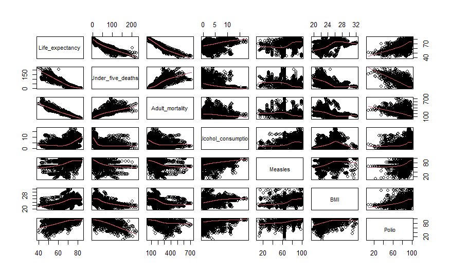

```r
pairs(Life_expectancy~Under_five_deaths+Adult_mortality+Alcohol_consumption+Measles+BMI+Polio,data=LifeExpectancy, panel = panel.smooth)
```

```r
NA
NA
```

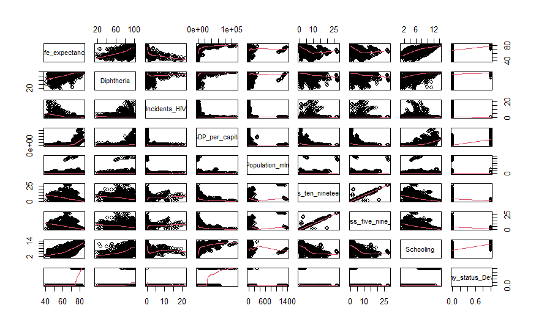

```r
pairs(Life_expectancy~Diphtheria+Incidents_HIV+GDP_per_capita+Population_mln+Thinness_ten_nineteen_years+Thinness_five_nine_years+Schooling+Economy_status_Developed,data=LifeExpectancy, panel = panel.smooth)
```

try incidents HIV, bmi, schooling, hiv, gdp per capita, thinnest ten-ninteen

BMI Higher Order

```r
HigherOrderModel <- lm(
   Life_expectancy ~
    Under_five_deaths +
    Adult_mortality +
    Alcohol_consumption +
    BMI +
    I(BMI^2)+
    I(BMI^3)+
    I(BMI^4)+
    I(BMI^5)+
    Incidents_HIV +
    GDP_per_capita +
    Thinness_ten_nineteen_years +
    Schooling +
    Economy_status_Developed +
    Under_five_deaths:Adult_mortality +
    Under_five_deaths:Alcohol_consumption +
    Under_five_deaths:BMI +
    Under_five_deaths:Incidents_HIV+
    Under_five_deaths:GDP_per_capita+
    Under_five_deaths:Schooling +
    Under_five_deaths:Economy_status_Developed+
    Adult_mortality:BMI +
    Adult_mortality:Incidents_HIV +
    Adult_mortality:GDP_per_capita +
    Alcohol_consumption:BMI +
    Alcohol_consumption:Incidents_HIV +
    Alcohol_consumption:GDP_per_capita +
    Alcohol_consumption:Thinness_ten_nineteen_years +
    Alcohol_consumption:Schooling +
    Alcohol_consumption:Economy_status_Developed +
    BMI:Thinness_ten_nineteen_years+
    BMI:Schooling+
    BMI:Economy_status_Developed+
    Incidents_HIV:Schooling +
    Incidents_HIV:Economy_status_Developed +
    GDP_per_capita:Thinness_ten_nineteen_years +
    GDP_per_capita:Schooling +
    GDP_per_capita:Economy_status_Developed+
    Schooling:Economy_status_Developed  ,
  data = LifeExpectancy

)
summary(HigherOrderModel)
```

```
Call:
lm(formula = Life_expectancy ~ Under_five_deaths + Adult_mortality +
    Alcohol_consumption + BMI + I(BMI^2) + I(BMI^3) + I(BMI^4) +
    I(BMI^5) + Incidents_HIV + GDP_per_capita + Thinness_ten_nineteen_years +
    Schooling + Economy_status_Developed + Under_five_deaths:Adult_mortality +
    Under_five_deaths:Alcohol_consumption + Under_five_deaths:BMI +
    Under_five_deaths:Incidents_HIV + Under_five_deaths:GDP_per_capita +
    Under_five_deaths:Schooling + Under_five_deaths:Economy_status_Developed +
    Adult_mortality:BMI + Adult_mortality:Incidents_HIV + Adult_mortality:GDP_per_capita +
    Alcohol_consumption:BMI + Alcohol_consumption:Incidents_HIV +
    Alcohol_consumption:GDP_per_capita + Alcohol_consumption:Thinness_ten_nineteen_years +
    Alcohol_consumption:Schooling + Alcohol_consumption:Economy_status_Developed +
    BMI:Thinness_ten_nineteen_years + BMI:Schooling + BMI:Economy_status_Developed +
    Incidents_HIV:Schooling + Incidents_HIV:Economy_status_Developed +
    GDP_per_capita:Thinness_ten_nineteen_years + GDP_per_capita:Schooling +
    GDP_per_capita:Economy_status_Developed + Schooling:Economy_status_Developed,
    data = LifeExpectancy)

Residuals:
    Min      1Q  Median      3Q     Max
-4.2460 -0.6997  0.0153  0.6591  8.5376

Coefficients:
                                                  Estimate Std. Error t value Pr(>|t|)
(Intercept)                                     -2.292e+03  1.239e+03  -1.850  0.06446 .
Under_five_deaths                               -2.848e-01  1.948e-02 -14.616  < 2e-16 ***
Adult_mortality                                  4.381e-03  6.531e-03   0.671  0.50244
Alcohol_consumption                             -6.907e-01  1.690e-01  -4.088 4.48e-05 ***
BMI                                              5.165e+02  2.467e+02   2.094  0.03635 *
I(BMI^2)                                        -4.421e+01  1.954e+01  -2.263  0.02372 *
I(BMI^3)                                         1.861e+00  7.696e-01   2.418  0.01566 *
I(BMI^4)                                        -3.857e-02  1.508e-02  -2.558  0.01057 *
I(BMI^5)                                         3.153e-04  1.175e-04   2.683  0.00734 **
Incidents_HIV                                   -1.259e+00  1.023e-01 -12.308  < 2e-16 ***
GDP_per_capita                                  -3.072e-06  1.999e-05  -0.154  0.87788
Thinness_ten_nineteen_years                     -1.540e-01  9.169e-02  -1.680  0.09309 .
Schooling                                        1.428e+00  2.189e-01   6.526 7.96e-11 ***
Economy_status_Developed                         9.070e+00  1.978e+00   4.584 4.75e-06 ***
Under_five_deaths:Adult_mortality                1.071e-04  9.631e-06  11.124  < 2e-16 ***
Under_five_deaths:Alcohol_consumption           -1.152e-03  3.503e-04  -3.287  0.00103 **
```

[output cut: 14 more lines]

```
BMI:Thinness_ten_nineteen_years                  9.473e-03  4.138e-03   2.289  0.02213 *
BMI:Schooling                                   -4.950e-02  8.458e-03  -5.853 5.40e-09 ***
BMI:Economy_status_Developed                    -2.962e-01  7.453e-02  -3.974 7.24e-05 ***
Incidents_HIV:Schooling                          1.233e-01  8.554e-03  14.410  < 2e-16 ***
Incidents_HIV:Economy_status_Developed           9.409e+00  1.070e+00   8.792  < 2e-16 ***
GDP_per_capita:Thinness_ten_nineteen_years      -1.175e-05  1.717e-06  -6.840 9.68e-12 ***
GDP_per_capita:Schooling                         6.643e-06  1.639e-06   4.053 5.19e-05 ***
GDP_per_capita:Economy_status_Developed         -6.502e-05  9.635e-06  -6.749 1.80e-11 ***
Schooling:Economy_status_Developed               1.732e-01  6.750e-02   2.566  0.01035 *
---
Signif. codes:  0 ‘***’ 0.001 ‘**’ 0.01 ‘*’ 0.05 ‘.’ 0.1 ‘ ’ 1

Residual standard error: 1.063 on 2825 degrees of freedom
Multiple R-squared:  0.9874,    Adjusted R-squared:  0.9872
F-statistic:  5819 on 38 and 2825 DF,  p-value: < 2.2e-16
```

Incidents HIV Higher Order

```r
HigherOrderModel2 <- lm(
   Life_expectancy ~
    Under_five_deaths +
    Adult_mortality +
    Alcohol_consumption +
    BMI +
    I(BMI^2)+
    I(BMI^3)+
    I(BMI^4)+
    I(BMI^5)+
    Incidents_HIV +
    I(Incidents_HIV^2)+
    I(Incidents_HIV^3)+
    I(Incidents_HIV^4)+
    I(Incidents_HIV^5)+
    I(Incidents_HIV^6)+
    GDP_per_capita +
    Thinness_ten_nineteen_years +
    Schooling +
    Economy_status_Developed +
    Under_five_deaths:Adult_mortality +
    Under_five_deaths:Alcohol_consumption +
    Under_five_deaths:BMI +
    Under_five_deaths:Incidents_HIV+
    Under_five_deaths:GDP_per_capita+
    Under_five_deaths:Schooling +
    Under_five_deaths:Economy_status_Developed+
    Adult_mortality:BMI +
    Adult_mortality:Incidents_HIV +
    Adult_mortality:GDP_per_capita +
    Alcohol_consumption:BMI +
    Alcohol_consumption:Incidents_HIV +
    Alcohol_consumption:GDP_per_capita +
    Alcohol_consumption:Thinness_ten_nineteen_years +
    Alcohol_consumption:Schooling +
    Alcohol_consumption:Economy_status_Developed +
    BMI:Thinness_ten_nineteen_years+
    BMI:Schooling+
    BMI:Economy_status_Developed+
    Incidents_HIV:Schooling +
    Incidents_HIV:Economy_status_Developed +
    GDP_per_capita:Thinness_ten_nineteen_years +
    GDP_per_capita:Schooling +
    GDP_per_capita:Economy_status_Developed+
    Schooling:Economy_status_Developed  ,
  data = LifeExpectancy

)
summary(HigherOrderModel2)
```

```
Call:
lm(formula = Life_expectancy ~ Under_five_deaths + Adult_mortality +
    Alcohol_consumption + BMI + I(BMI^2) + I(BMI^3) + I(BMI^4) +
    I(BMI^5) + Incidents_HIV + I(Incidents_HIV^2) + I(Incidents_HIV^3) +
    I(Incidents_HIV^4) + I(Incidents_HIV^5) + I(Incidents_HIV^6) +
    GDP_per_capita + Thinness_ten_nineteen_years + Schooling +
    Economy_status_Developed + Under_five_deaths:Adult_mortality +
    Under_five_deaths:Alcohol_consumption + Under_five_deaths:BMI +
    Under_five_deaths:Incidents_HIV + Under_five_deaths:GDP_per_capita +
    Under_five_deaths:Schooling + Under_five_deaths:Economy_status_Developed +
    Adult_mortality:BMI + Adult_mortality:Incidents_HIV + Adult_mortality:GDP_per_capita +
    Alcohol_consumption:BMI + Alcohol_consumption:Incidents_HIV +
    Alcohol_consumption:GDP_per_capita + Alcohol_consumption:Thinness_ten_nineteen_years +
    Alcohol_consumption:Schooling + Alcohol_consumption:Economy_status_Developed +
    BMI:Thinness_ten_nineteen_years + BMI:Schooling + BMI:Economy_status_Developed +
    Incidents_HIV:Schooling + Incidents_HIV:Economy_status_Developed +
    GDP_per_capita:Thinness_ten_nineteen_years + GDP_per_capita:Schooling +
    GDP_per_capita:Economy_status_Developed + Schooling:Economy_status_Developed,
    data = LifeExpectancy)

Residuals:
    Min      1Q  Median      3Q     Max
-4.2875 -0.6773 -0.0064  0.6315  8.4952

Coefficients:
                                                  Estimate Std. Error t value Pr(>|t|)
(Intercept)                                     -1.989e+03  1.216e+03  -1.636 0.101996
Under_five_deaths                               -2.783e-01  1.922e-02 -14.476  < 2e-16 ***
Adult_mortality                                 -1.141e-02  6.749e-03  -1.690 0.091080 .
Alcohol_consumption                             -6.537e-01  1.666e-01  -3.924 8.93e-05 ***
BMI                                              4.615e+02  2.421e+02   1.907 0.056682 .
I(BMI^2)                                        -4.021e+01  1.917e+01  -2.097 0.036060 *
I(BMI^3)                                         1.716e+00  7.552e-01   2.272 0.023146 *
I(BMI^4)                                        -3.596e-02  1.480e-02  -2.430 0.015141 *
I(BMI^5)                                         2.966e-04  1.153e-04   2.572 0.010174 *
Incidents_HIV                                   -2.301e+00  1.880e-01 -12.242  < 2e-16 ***
I(Incidents_HIV^2)                               5.655e-01  9.471e-02   5.971 2.65e-09 ***
I(Incidents_HIV^3)                              -1.028e-01  2.151e-02  -4.778 1.86e-06 ***
I(Incidents_HIV^4)                               8.294e-03  2.194e-03   3.781 0.000160 ***
I(Incidents_HIV^5)                              -3.194e-04  1.016e-04  -3.142 0.001695 **
```

[output cut: 21 more lines]

```
BMI:Thinness_ten_nineteen_years                  1.184e-02  4.070e-03   2.910 0.003643 **
BMI:Schooling                                   -3.988e-02  8.339e-03  -4.782 1.82e-06 ***
BMI:Economy_status_Developed                    -3.143e-01  7.331e-02  -4.287 1.87e-05 ***
Incidents_HIV:Schooling                          1.337e-01  1.058e-02  12.641  < 2e-16 ***
Incidents_HIV:Economy_status_Developed           1.021e+01  1.053e+00   9.701  < 2e-16 ***
GDP_per_capita:Thinness_ten_nineteen_years      -1.274e-05  1.690e-06  -7.536 6.47e-14 ***
GDP_per_capita:Schooling                         6.462e-06  1.605e-06   4.027 5.81e-05 ***
GDP_per_capita:Economy_status_Developed         -7.273e-05  9.510e-06  -7.648 2.78e-14 ***
Schooling:Economy_status_Developed               2.352e-01  6.656e-02   3.534 0.000417 ***
---
Signif. codes:  0 ‘***’ 0.001 ‘**’ 0.01 ‘*’ 0.05 ‘.’ 0.1 ‘ ’ 1

Residual standard error: 1.041 on 2820 degrees of freedom
Multiple R-squared:  0.9879,    Adjusted R-squared:  0.9878
F-statistic:  5372 on 43 and 2820 DF,  p-value: < 2.2e-16
```

gdp per capita higher order

```r
HigherOrderModel3 <- lm(
   Life_expectancy ~
    Under_five_deaths +
    Adult_mortality +
    Alcohol_consumption +
    BMI +
    I(BMI^2)+
    I(BMI^3)+
    I(BMI^4)+
    I(BMI^5)+
    Incidents_HIV +
    I(Incidents_HIV^2)+
    I(Incidents_HIV^3)+
    I(Incidents_HIV^4)+
    I(Incidents_HIV^5)+
    I(Incidents_HIV^6)+
    GDP_per_capita +
    I(GDP_per_capita^2) +
    I(GDP_per_capita^3) +
    I(GDP_per_capita^4) +
    I(GDP_per_capita^5) +
    I(GDP_per_capita^6) +
    Thinness_ten_nineteen_years +
    Schooling +
    Economy_status_Developed +
    Under_five_deaths:Adult_mortality +
    Under_five_deaths:Alcohol_consumption +
    Under_five_deaths:BMI +
    Under_five_deaths:Incidents_HIV+
    Under_five_deaths:GDP_per_capita+
    Under_five_deaths:Schooling +
    Under_five_deaths:Economy_status_Developed+
    Adult_mortality:BMI +
    Adult_mortality:Incidents_HIV +
    Adult_mortality:GDP_per_capita +
    Alcohol_consumption:BMI +
    Alcohol_consumption:Incidents_HIV +
    Alcohol_consumption:GDP_per_capita +
    Alcohol_consumption:Thinness_ten_nineteen_years +
    Alcohol_consumption:Schooling +
    Alcohol_consumption:Economy_status_Developed +
    BMI:Thinness_ten_nineteen_years+
    BMI:Schooling+
    BMI:Economy_status_Developed+
    Incidents_HIV:Schooling +
    Incidents_HIV:Economy_status_Developed +
    GDP_per_capita:Thinness_ten_nineteen_years +
    GDP_per_capita:Schooling +
    GDP_per_capita:Economy_status_Developed+
    Schooling:Economy_status_Developed  ,
  data = LifeExpectancy

)
summary(HigherOrderModel3)
```

```
Call:
lm(formula = Life_expectancy ~ Under_five_deaths + Adult_mortality +
    Alcohol_consumption + BMI + I(BMI^2) + I(BMI^3) + I(BMI^4) +
    I(BMI^5) + Incidents_HIV + I(Incidents_HIV^2) + I(Incidents_HIV^3) +
    I(Incidents_HIV^4) + I(Incidents_HIV^5) + I(Incidents_HIV^6) +
    GDP_per_capita + I(GDP_per_capita^2) + I(GDP_per_capita^3) +
    I(GDP_per_capita^4) + I(GDP_per_capita^5) + I(GDP_per_capita^6) +
    Thinness_ten_nineteen_years + Schooling + Economy_status_Developed +
    Under_five_deaths:Adult_mortality + Under_five_deaths:Alcohol_consumption +
    Under_five_deaths:BMI + Under_five_deaths:Incidents_HIV +
    Under_five_deaths:GDP_per_capita + Under_five_deaths:Schooling +
    Under_five_deaths:Economy_status_Developed + Adult_mortality:BMI +
    Adult_mortality:Incidents_HIV + Adult_mortality:GDP_per_capita +
    Alcohol_consumption:BMI + Alcohol_consumption:Incidents_HIV +
    Alcohol_consumption:GDP_per_capita + Alcohol_consumption:Thinness_ten_nineteen_years +
    Alcohol_consumption:Schooling + Alcohol_consumption:Economy_status_Developed +
    BMI:Thinness_ten_nineteen_years + BMI:Schooling + BMI:Economy_status_Developed +
    Incidents_HIV:Schooling + Incidents_HIV:Economy_status_Developed +
    GDP_per_capita:Thinness_ten_nineteen_years + GDP_per_capita:Schooling +
    GDP_per_capita:Economy_status_Developed + Schooling:Economy_status_Developed,
    data = LifeExpectancy)

Residuals:
    Min      1Q  Median      3Q     Max
-4.2547 -0.6395 -0.0238  0.5916  8.1842

Coefficients:
                                                  Estimate Std. Error t value Pr(>|t|)
(Intercept)                                     -2.394e+03  1.196e+03  -2.001 0.045460 *
Under_five_deaths                               -2.780e-01  1.903e-02 -14.613  < 2e-16 ***
Adult_mortality                                 -1.066e-02  6.642e-03  -1.605 0.108539
Alcohol_consumption                             -5.598e-01  1.639e-01  -3.415 0.000646 ***
BMI                                              5.367e+02  2.381e+02   2.254 0.024285 *
I(BMI^2)                                        -4.573e+01  1.886e+01  -2.424 0.015393 *
I(BMI^3)                                         1.916e+00  7.431e-01   2.579 0.009969 **
I(BMI^4)                                        -3.954e-02  1.456e-02  -2.716 0.006651 **
I(BMI^5)                                         3.218e-04  1.135e-04   2.836 0.004603 **
Incidents_HIV                                   -2.471e+00  1.861e-01 -13.279  < 2e-16 ***
I(Incidents_HIV^2)                               6.242e-01  9.323e-02   6.695 2.60e-11 ***
I(Incidents_HIV^3)                              -1.153e-01  2.116e-02  -5.446 5.59e-08 ***
```

[output cut: 28 more lines]

```
BMI:Thinness_ten_nineteen_years                  6.617e-03  4.050e-03   1.634 0.102406
BMI:Schooling                                   -3.280e-02  8.266e-03  -3.968 7.43e-05 ***
BMI:Economy_status_Developed                    -2.553e-01  7.295e-02  -3.500 0.000472 ***
Incidents_HIV:Schooling                          1.275e-01  1.042e-02  12.235  < 2e-16 ***
Incidents_HIV:Economy_status_Developed           1.054e+01  1.038e+00  10.157  < 2e-16 ***
GDP_per_capita:Thinness_ten_nineteen_years      -1.071e-05  1.687e-06  -6.348 2.54e-10 ***
GDP_per_capita:Schooling                         6.289e-06  1.693e-06   3.714 0.000208 ***
GDP_per_capita:Economy_status_Developed         -7.144e-05  9.932e-06  -7.193 8.10e-13 ***
Schooling:Economy_status_Developed               1.562e-01  6.701e-02   2.331 0.019807 *
---
Signif. codes:  0 ‘***’ 0.001 ‘**’ 0.01 ‘*’ 0.05 ‘.’ 0.1 ‘ ’ 1

Residual standard error: 1.021 on 2815 degrees of freedom
Multiple R-squared:  0.9884,    Adjusted R-squared:  0.9882
F-statistic:  5004 on 48 and 2815 DF,  p-value: < 2.2e-16
```

thinness higher order

```r
HigherOrderModel4 <- lm(
   Life_expectancy ~
    Under_five_deaths +
    Adult_mortality +
    Alcohol_consumption +
    BMI +
    I(BMI^2)+
    I(BMI^3)+
    I(BMI^4)+
    I(BMI^5)+
    Incidents_HIV +
    I(Incidents_HIV^2)+
    I(Incidents_HIV^3)+
    I(Incidents_HIV^4)+
    I(Incidents_HIV^5)+
    I(Incidents_HIV^6)+
    GDP_per_capita +
    I(GDP_per_capita^2) +
    I(GDP_per_capita^3) +
    I(GDP_per_capita^4) +
    I(GDP_per_capita^5) +
    I(GDP_per_capita^6) +
    Thinness_ten_nineteen_years +
    I(Thinness_ten_nineteen_years^2) +
    I(Thinness_ten_nineteen_years^3) +
    I(Thinness_ten_nineteen_years^4) +
    I(Thinness_ten_nineteen_years^5) +
    Schooling+
    Economy_status_Developed +
    Under_five_deaths:Adult_mortality +
    Under_five_deaths:Alcohol_consumption +
    Under_five_deaths:BMI +
    Under_five_deaths:Incidents_HIV+
    Under_five_deaths:GDP_per_capita+
    Under_five_deaths:Schooling +
    Under_five_deaths:Economy_status_Developed+
    Adult_mortality:BMI +
    Adult_mortality:Incidents_HIV +
    Adult_mortality:GDP_per_capita +
    Alcohol_consumption:BMI +
    Alcohol_consumption:Incidents_HIV +
    Alcohol_consumption:GDP_per_capita +
    Alcohol_consumption:Thinness_ten_nineteen_years +
    Alcohol_consumption:Schooling +
    Alcohol_consumption:Economy_status_Developed +
    BMI:Thinness_ten_nineteen_years+
    BMI:Schooling+
    BMI:Economy_status_Developed+
    Incidents_HIV:Schooling +
    Incidents_HIV:Economy_status_Developed +
    GDP_per_capita:Thinness_ten_nineteen_years +
    GDP_per_capita:Schooling +
    GDP_per_capita:Economy_status_Developed+
    Schooling:Economy_status_Developed  ,
  data = LifeExpectancy

)
summary(HigherOrderModel4)
```

```
Call:
lm(formula = Life_expectancy ~ Under_five_deaths + Adult_mortality +
    Alcohol_consumption + BMI + I(BMI^2) + I(BMI^3) + I(BMI^4) +
    I(BMI^5) + Incidents_HIV + I(Incidents_HIV^2) + I(Incidents_HIV^3) +
    I(Incidents_HIV^4) + I(Incidents_HIV^5) + I(Incidents_HIV^6) +
    GDP_per_capita + I(GDP_per_capita^2) + I(GDP_per_capita^3) +
    I(GDP_per_capita^4) + I(GDP_per_capita^5) + I(GDP_per_capita^6) +
    Thinness_ten_nineteen_years + I(Thinness_ten_nineteen_years^2) +
    I(Thinness_ten_nineteen_years^3) + I(Thinness_ten_nineteen_years^4) +
    I(Thinness_ten_nineteen_years^5) + Schooling + Economy_status_Developed +
    Under_five_deaths:Adult_mortality + Under_five_deaths:Alcohol_consumption +
    Under_five_deaths:BMI + Under_five_deaths:Incidents_HIV +
    Under_five_deaths:GDP_per_capita + Under_five_deaths:Schooling +
    Under_five_deaths:Economy_status_Developed + Adult_mortality:BMI +
    Adult_mortality:Incidents_HIV + Adult_mortality:GDP_per_capita +
    Alcohol_consumption:BMI + Alcohol_consumption:Incidents_HIV +
    Alcohol_consumption:GDP_per_capita + Alcohol_consumption:Thinness_ten_nineteen_years +
    Alcohol_consumption:Schooling + Alcohol_consumption:Economy_status_Developed +
    BMI:Thinness_ten_nineteen_years + BMI:Schooling + BMI:Economy_status_Developed +
    Incidents_HIV:Schooling + Incidents_HIV:Economy_status_Developed +
    GDP_per_capita:Thinness_ten_nineteen_years + GDP_per_capita:Schooling +
    GDP_per_capita:Economy_status_Developed + Schooling:Economy_status_Developed,
    data = LifeExpectancy)

Residuals:
    Min      1Q  Median      3Q     Max
-4.0672 -0.6443 -0.0030  0.6047  7.8052

Coefficients:
                                                  Estimate Std. Error t value Pr(>|t|)
(Intercept)                                     -1.367e+03  1.192e+03  -1.147 0.251439
Under_five_deaths                               -2.879e-01  1.906e-02 -15.107  < 2e-16 ***
Adult_mortality                                 -3.773e-03  6.617e-03  -0.570 0.568636
Alcohol_consumption                             -3.803e-01  1.652e-01  -2.303 0.021377 *
BMI                                              3.387e+02  2.372e+02   1.428 0.153443
I(BMI^2)                                        -3.056e+01  1.879e+01  -1.627 0.103950
I(BMI^3)                                         1.338e+00  7.399e-01   1.808 0.070655 .
I(BMI^4)                                        -2.860e-02  1.449e-02  -1.973 0.048580 *
I(BMI^5)                                         2.396e-04  1.129e-04   2.121 0.034005 *
Incidents_HIV                                   -2.344e+00  1.857e-01 -12.628  < 2e-16 ***
```

[output cut: 34 more lines]

```
BMI:Thinness_ten_nineteen_years                  1.816e-02  4.920e-03   3.692 0.000227 ***
BMI:Schooling                                   -3.521e-02  8.201e-03  -4.294 1.82e-05 ***
BMI:Economy_status_Developed                    -1.378e-01  7.517e-02  -1.833 0.066922 .
Incidents_HIV:Schooling                          1.306e-01  1.040e-02  12.558  < 2e-16 ***
Incidents_HIV:Economy_status_Developed           1.039e+01  1.026e+00  10.129  < 2e-16 ***
GDP_per_capita:Thinness_ten_nineteen_years      -9.817e-06  1.688e-06  -5.816 6.69e-09 ***
GDP_per_capita:Schooling                         6.921e-06  1.686e-06   4.104 4.17e-05 ***
GDP_per_capita:Economy_status_Developed         -6.554e-05  9.988e-06  -6.562 6.29e-11 ***
Schooling:Economy_status_Developed               1.512e-01  6.810e-02   2.221 0.026461 *
---
Signif. codes:  0 ‘***’ 0.001 ‘**’ 0.01 ‘*’ 0.05 ‘.’ 0.1 ‘ ’ 1

Residual standard error: 1.009 on 2811 degrees of freedom
Multiple R-squared:  0.9887,    Adjusted R-squared:  0.9885
F-statistic:  4732 on 52 and 2811 DF,  p-value: < 2.2e-16
```

schooling higher order

```r
HigherOrderModel4 <- lm(
   Life_expectancy ~
    Under_five_deaths +
    Adult_mortality +
    Alcohol_consumption +
    I(Alcohol_consumption^2)+
    I(Alcohol_consumption^3)+
    I(Alcohol_consumption^4)+
    I(Alcohol_consumption^5)+
    BMI +
    I(BMI^2)+
    I(BMI^3)+
    I(BMI^4)+
    I(BMI^5)+
    Incidents_HIV +
    I(Incidents_HIV^2)+
    I(Incidents_HIV^3)+
    I(Incidents_HIV^4)+
    I(Incidents_HIV^5)+
    I(Incidents_HIV^6)+
    GDP_per_capita +
    I(GDP_per_capita^2) +
    I(GDP_per_capita^3) +
    I(GDP_per_capita^4) +
    I(GDP_per_capita^5) +
    I(GDP_per_capita^6) +
    Thinness_ten_nineteen_years +
    I(Thinness_ten_nineteen_years^2) +
    I(Thinness_ten_nineteen_years^3) +
    I(Thinness_ten_nineteen_years^4) +
    I(Thinness_ten_nineteen_years^5) +
    Schooling+
    I(Schooling^2)+
    Economy_status_Developed +
    Under_five_deaths:Adult_mortality +
    Under_five_deaths:Alcohol_consumption +
    Under_five_deaths:BMI +
    Under_five_deaths:Incidents_HIV+
    Under_five_deaths:GDP_per_capita+
    Under_five_deaths:Schooling +
    Under_five_deaths:Economy_status_Developed+
    Adult_mortality:BMI +
    Adult_mortality:Incidents_HIV +
    Adult_mortality:GDP_per_capita +
    Alcohol_consumption:BMI +
    Alcohol_consumption:Incidents_HIV +
    Alcohol_consumption:GDP_per_capita +
    Alcohol_consumption:Thinness_ten_nineteen_years +
    Alcohol_consumption:Schooling +
    Alcohol_consumption:Economy_status_Developed +
    BMI:Thinness_ten_nineteen_years+
    BMI:Schooling+
    BMI:Economy_status_Developed+
    Incidents_HIV:Schooling +
    Incidents_HIV:Economy_status_Developed +
    GDP_per_capita:Thinness_ten_nineteen_years +
    GDP_per_capita:Schooling +
    GDP_per_capita:Economy_status_Developed+
    Schooling:Economy_status_Developed  ,
  data = LifeExpectancy

)
summary(HigherOrderModel4)
```

```
Call:
lm(formula = Life_expectancy ~ Under_five_deaths + Adult_mortality +
    Alcohol_consumption + I(Alcohol_consumption^2) + I(Alcohol_consumption^3) +
    I(Alcohol_consumption^4) + I(Alcohol_consumption^5) + BMI +
    I(BMI^2) + I(BMI^3) + I(BMI^4) + I(BMI^5) + Incidents_HIV +
    I(Incidents_HIV^2) + I(Incidents_HIV^3) + I(Incidents_HIV^4) +
    I(Incidents_HIV^5) + I(Incidents_HIV^6) + GDP_per_capita +
    I(GDP_per_capita^2) + I(GDP_per_capita^3) + I(GDP_per_capita^4) +
    I(GDP_per_capita^5) + I(GDP_per_capita^6) + Thinness_ten_nineteen_years +
    I(Thinness_ten_nineteen_years^2) + I(Thinness_ten_nineteen_years^3) +
    I(Thinness_ten_nineteen_years^4) + I(Thinness_ten_nineteen_years^5) +
    Schooling + I(Schooling^2) + Economy_status_Developed + Under_five_deaths:Adult_mortality +
    Under_five_deaths:Alcohol_consumption + Under_five_deaths:BMI +
    Under_five_deaths:Incidents_HIV + Under_five_deaths:GDP_per_capita +
    Under_five_deaths:Schooling + Under_five_deaths:Economy_status_Developed +
    Adult_mortality:BMI + Adult_mortality:Incidents_HIV + Adult_mortality:GDP_per_capita +
    Alcohol_consumption:BMI + Alcohol_consumption:Incidents_HIV +
    Alcohol_consumption:GDP_per_capita + Alcohol_consumption:Thinness_ten_nineteen_years +
    Alcohol_consumption:Schooling + Alcohol_consumption:Economy_status_Developed +
    BMI:Thinness_ten_nineteen_years + BMI:Schooling + BMI:Economy_status_Developed +
    Incidents_HIV:Schooling + Incidents_HIV:Economy_status_Developed +
    GDP_per_capita:Thinness_ten_nineteen_years + GDP_per_capita:Schooling +
    GDP_per_capita:Economy_status_Developed + Schooling:Economy_status_Developed,
    data = LifeExpectancy)

Residuals:
    Min      1Q  Median      3Q     Max
-3.8518 -0.6068  0.0098  0.6263  7.7479

Coefficients:
                                                  Estimate Std. Error t value Pr(>|t|)
(Intercept)                                     -1.096e+03  1.161e+03  -0.944 0.345098
Under_five_deaths                               -2.890e-01  1.873e-02 -15.428  < 2e-16 ***
Adult_mortality                                  6.584e-03  6.546e-03   1.006 0.314597
Alcohol_consumption                             -9.046e-01  2.005e-01  -4.512 6.68e-06 ***
I(Alcohol_consumption^2)                         2.534e-01  4.630e-02   5.473 4.82e-08 ***
I(Alcohol_consumption^3)                        -4.715e-02  7.669e-03  -6.148 8.96e-10 ***
I(Alcohol_consumption^4)                         3.217e-03  5.381e-04   5.979 2.53e-09 ***
I(Alcohol_consumption^5)                        -7.354e-05  1.334e-05  -5.515 3.81e-08 ***
BMI                                              2.854e+02  2.310e+02   1.236 0.216688
```

[output cut: 40 more lines]

```
BMI:Thinness_ten_nineteen_years                  2.246e-02  4.905e-03   4.580 4.85e-06 ***
BMI:Schooling                                   -2.395e-02  9.448e-03  -2.535 0.011313 *
BMI:Economy_status_Developed                    -1.421e-01  7.361e-02  -1.931 0.053636 .
Incidents_HIV:Schooling                          1.125e-01  1.027e-02  10.953  < 2e-16 ***
Incidents_HIV:Economy_status_Developed           1.083e+01  1.009e+00  10.738  < 2e-16 ***
GDP_per_capita:Thinness_ten_nineteen_years      -8.739e-06  1.682e-06  -5.194 2.20e-07 ***
GDP_per_capita:Schooling                         9.395e-06  1.671e-06   5.622 2.07e-08 ***
GDP_per_capita:Economy_status_Developed         -8.920e-05  1.014e-05  -8.799  < 2e-16 ***
Schooling:Economy_status_Developed               1.072e-01  6.824e-02   1.571 0.116380
---
Signif. codes:  0 ‘***’ 0.001 ‘**’ 0.01 ‘*’ 0.05 ‘.’ 0.1 ‘ ’ 1

Residual standard error: 0.9801 on 2806 degrees of freedom
Multiple R-squared:  0.9894,    Adjusted R-squared:  0.9891
F-statistic:  4576 on 57 and 2806 DF,  p-value: < 2.2e-16
```

# Final Model

remove now insignificant interactions

```r
FinalModel <- lm(
   Life_expectancy ~
    Under_five_deaths +
    Adult_mortality +
    Alcohol_consumption +
    I(Alcohol_consumption^2)+
    I(Alcohol_consumption^3)+
    I(Alcohol_consumption^4)+
    I(Alcohol_consumption^5)+
    BMI +
    I(BMI^2)+
    I(BMI^3)+
    I(BMI^4)+
    Incidents_HIV +
    I(Incidents_HIV^2)+
    I(Incidents_HIV^3)+
    I(Incidents_HIV^4)+
    I(Incidents_HIV^5)+
    I(Incidents_HIV^6)+
    GDP_per_capita +
    I(GDP_per_capita^2) +
    I(GDP_per_capita^3) +
    I(GDP_per_capita^4) +
    I(GDP_per_capita^5) +
    I(GDP_per_capita^6) +
    Thinness_ten_nineteen_years +
    I(Thinness_ten_nineteen_years^2) +
    I(Thinness_ten_nineteen_years^3) +
    I(Thinness_ten_nineteen_years^4) +
    I(Thinness_ten_nineteen_years^5) +
    Schooling+
    I(Schooling^2)+
    Economy_status_Developed +
    Under_five_deaths:Adult_mortality +
    Under_five_deaths:Alcohol_consumption +
    Under_five_deaths:BMI +
    Under_five_deaths:Incidents_HIV+
    Under_five_deaths:Schooling +
    Under_five_deaths:Economy_status_Developed+
    Adult_mortality:BMI +
    Adult_mortality:Incidents_HIV +
    Adult_mortality:GDP_per_capita +
    Alcohol_consumption:BMI +
    Alcohol_consumption:Incidents_HIV +
    Alcohol_consumption:GDP_per_capita +
    Alcohol_consumption:Schooling +
    Alcohol_consumption:Economy_status_Developed +
    BMI:Thinness_ten_nineteen_years+
    BMI:Schooling+
    Incidents_HIV:Schooling +
    Incidents_HIV:Economy_status_Developed +
    GDP_per_capita:Thinness_ten_nineteen_years +
    GDP_per_capita:Schooling +
    GDP_per_capita:Economy_status_Developed,
  data = LifeExpectancy

)
summary(FinalModel)
```

```
Call:
lm(formula = Life_expectancy ~ Under_five_deaths + Adult_mortality +
    Alcohol_consumption + I(Alcohol_consumption^2) + I(Alcohol_consumption^3) +
    I(Alcohol_consumption^4) + I(Alcohol_consumption^5) + BMI +
    I(BMI^2) + I(BMI^3) + I(BMI^4) + Incidents_HIV + I(Incidents_HIV^2) +
    I(Incidents_HIV^3) + I(Incidents_HIV^4) + I(Incidents_HIV^5) +
    I(Incidents_HIV^6) + GDP_per_capita + I(GDP_per_capita^2) +
    I(GDP_per_capita^3) + I(GDP_per_capita^4) + I(GDP_per_capita^5) +
    I(GDP_per_capita^6) + Thinness_ten_nineteen_years + I(Thinness_ten_nineteen_years^2) +
    I(Thinness_ten_nineteen_years^3) + I(Thinness_ten_nineteen_years^4) +
    I(Thinness_ten_nineteen_years^5) + Schooling + I(Schooling^2) +
    Economy_status_Developed + Under_five_deaths:Adult_mortality +
    Under_five_deaths:Alcohol_consumption + Under_five_deaths:BMI +
    Under_five_deaths:Incidents_HIV + Under_five_deaths:Schooling +
    Under_five_deaths:Economy_status_Developed + Adult_mortality:BMI +
    Adult_mortality:Incidents_HIV + Adult_mortality:GDP_per_capita +
    Alcohol_consumption:BMI + Alcohol_consumption:Incidents_HIV +
    Alcohol_consumption:GDP_per_capita + Alcohol_consumption:Schooling +
    Alcohol_consumption:Economy_status_Developed + BMI:Thinness_ten_nineteen_years +
    BMI:Schooling + Incidents_HIV:Schooling + Incidents_HIV:Economy_status_Developed +
    GDP_per_capita:Thinness_ten_nineteen_years + GDP_per_capita:Schooling +
    GDP_per_capita:Economy_status_Developed, data = LifeExpectancy)

Residuals:
    Min      1Q  Median      3Q     Max
-3.8862 -0.5928  0.0163  0.6248  7.7101

Coefficients:
                                               Estimate Std. Error t value Pr(>|t|)
(Intercept)                                   1.199e+03  1.413e+02   8.490  < 2e-16 ***
Under_five_deaths                            -2.801e-01  1.796e-02 -15.597  < 2e-16 ***
Adult_mortality                               5.279e-03  6.333e-03   0.834 0.404570
Alcohol_consumption                          -8.051e-01  1.843e-01  -4.369 1.29e-05 ***
I(Alcohol_consumption^2)                      2.535e-01  4.614e-02   5.494 4.28e-08 ***
I(Alcohol_consumption^3)                     -4.733e-02  7.645e-03  -6.191 6.86e-10 ***
I(Alcohol_consumption^4)                      3.228e-03  5.366e-04   6.016 2.02e-09 ***
I(Alcohol_consumption^5)                     -7.369e-05  1.330e-05  -5.540 3.31e-08 ***
BMI                                          -1.718e+02  2.220e+01  -7.742 1.36e-14 ***
I(BMI^2)                                      9.787e+00  1.300e+00   7.529 6.82e-14 ***
I(BMI^3)                                     -2.460e-01  3.364e-02  -7.310 3.46e-13 ***
```

[output cut: 33 more lines]

```
Alcohol_consumption:Schooling                -1.104e-02  4.564e-03  -2.418 0.015675 *
Alcohol_consumption:Economy_status_Developed -2.825e-01  3.575e-02  -7.903 3.89e-15 ***
BMI:Thinness_ten_nineteen_years               2.128e-02  4.807e-03   4.428 9.89e-06 ***
BMI:Schooling                                -2.941e-02  8.796e-03  -3.344 0.000837 ***
Incidents_HIV:Schooling                       1.104e-01  1.014e-02  10.884  < 2e-16 ***
Incidents_HIV:Economy_status_Developed        1.083e+01  1.000e+00  10.830  < 2e-16 ***
GDP_per_capita:Thinness_ten_nineteen_years   -7.590e-06  1.566e-06  -4.845 1.33e-06 ***
GDP_per_capita:Schooling                      1.029e-05  1.361e-06   7.559 5.46e-14 ***
GDP_per_capita:Economy_status_Developed      -8.785e-05  9.942e-06  -8.837  < 2e-16 ***
---
Signif. codes:  0 ‘***’ 0.001 ‘**’ 0.01 ‘*’ 0.05 ‘.’ 0.1 ‘ ’ 1

Residual standard error: 0.9811 on 2811 degrees of freedom
Multiple R-squared:  0.9893,    Adjusted R-squared:  0.9891
F-statistic:  5006 on 52 and 2811 DF,  p-value: < 2.2e-16
```

Confirm if reduced model is valid

```r
anova(FinalModel,HigherOrderModel4)
```

```
Analysis of Variance Table

Model 1: Life_expectancy ~ Under_five_deaths + Adult_mortality + Alcohol_consumption +
    I(Alcohol_consumption^2) + I(Alcohol_consumption^3) + I(Alcohol_consumption^4) +
    I(Alcohol_consumption^5) + BMI + I(BMI^2) + I(BMI^3) + I(BMI^4) +
    Incidents_HIV + I(Incidents_HIV^2) + I(Incidents_HIV^3) +
    I(Incidents_HIV^4) + I(Incidents_HIV^5) + I(Incidents_HIV^6) +
    GDP_per_capita + I(GDP_per_capita^2) + I(GDP_per_capita^3) +
    I(GDP_per_capita^4) + I(GDP_per_capita^5) + I(GDP_per_capita^6) +
    Thinness_ten_nineteen_years + I(Thinness_ten_nineteen_years^2) +
    I(Thinness_ten_nineteen_years^3) + I(Thinness_ten_nineteen_years^4) +
    I(Thinness_ten_nineteen_years^5) + Schooling + I(Schooling^2) +
    Economy_status_Developed + Under_five_deaths:Adult_mortality +
    Under_five_deaths:Alcohol_consumption + Under_five_deaths:BMI +
    Under_five_deaths:Incidents_HIV + Under_five_deaths:Schooling +
    Under_five_deaths:Economy_status_Developed + Adult_mortality:BMI +
    Adult_mortality:Incidents_HIV + Adult_mortality:GDP_per_capita +
    Alcohol_consumption:BMI + Alcohol_consumption:Incidents_HIV +
    Alcohol_consumption:GDP_per_capita + Alcohol_consumption:Schooling +
    Alcohol_consumption:Economy_status_Developed + BMI:Thinness_ten_nineteen_years +
    BMI:Schooling + Incidents_HIV:Schooling + Incidents_HIV:Economy_status_Developed +
    GDP_per_capita:Thinness_ten_nineteen_years + GDP_per_capita:Schooling +
    GDP_per_capita:Economy_status_Developed
Model 2: Life_expectancy ~ Under_five_deaths + Adult_mortality + Alcohol_consumption +
    I(Alcohol_consumption^2) + I(Alcohol_consumption^3) + I(Alcohol_consumption^4) +
    I(Alcohol_consumption^5) + BMI + I(BMI^2) + I(BMI^3) + I(BMI^4) +
    I(BMI^5) + Incidents_HIV + I(Incidents_HIV^2) + I(Incidents_HIV^3) +
    I(Incidents_HIV^4) + I(Incidents_HIV^5) + I(Incidents_HIV^6) +
    GDP_per_capita + I(GDP_per_capita^2) + I(GDP_per_capita^3) +
    I(GDP_per_capita^4) + I(GDP_per_capita^5) + I(GDP_per_capita^6) +
    Thinness_ten_nineteen_years + I(Thinness_ten_nineteen_years^2) +
    I(Thinness_ten_nineteen_years^3) + I(Thinness_ten_nineteen_years^4) +
    I(Thinness_ten_nineteen_years^5) + Schooling + I(Schooling^2) +
    Economy_status_Developed + Under_five_deaths:Adult_mortality +
    Under_five_deaths:Alcohol_consumption + Under_five_deaths:BMI +
    Under_five_deaths:Incidents_HIV + Under_five_deaths:GDP_per_capita +
    Under_five_deaths:Schooling + Under_five_deaths:Economy_status_Developed +
    Adult_mortality:BMI + Adult_mortality:Incidents_HIV + Adult_mortality:GDP_per_capita +
    Alcohol_consumption:BMI + Alcohol_consumption:Incidents_HIV +
    Alcohol_consumption:GDP_per_capita + Alcohol_consumption:Thinness_ten_nineteen_years +
    Alcohol_consumption:Schooling + Alcohol_consumption:Economy_status_Developed +
    BMI:Thinness_ten_nineteen_years + BMI:Schooling + BMI:Economy_status_Developed +
    Incidents_HIV:Schooling + Incidents_HIV:Economy_status_Developed +
    GDP_per_capita:Thinness_ten_nineteen_years + GDP_per_capita:Schooling +
    GDP_per_capita:Economy_status_Developed + Schooling:Economy_status_Developed
  Res.Df    RSS Df Sum of Sq      F  Pr(>F)
1   2811 2705.6
2   2806 2695.5  5     10.08 2.0987 0.06274 .
---
Signif. codes:  0 ‘***’ 0.001 ‘**’ 0.01 ‘*’ 0.05 ‘.’ 0.1 ‘ ’ 1
```

We go with the reduced model